# About

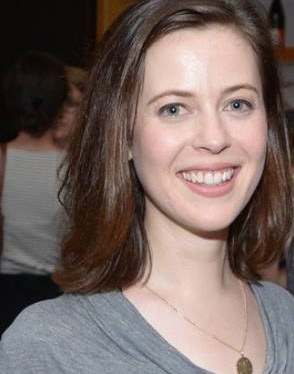

I am currently pursuing my MS in Biostatistics at [Columbia University Mailman School of Public Health](https://www.mailman.columbia.edu/). I am conducting research with [Ronglai Shen](https://www.mskcc.org/profile/ronglai-shen) at [Memorial Sloan Kettering Cancer Center](https://www.mskcc.org/) and [Shuang Wang](https://www.mailman.columbia.edu/people/our-faculty/sw2206) in the [Department of Biostatistics at Columbia University](https://www.mailman.columbia.edu/become-student/departments/biostatistics) using multimodal genomic data from [The Cancer Genome Atlas](https://cancergenome.nih.gov/) to validate and refine breast cancer subtype classifications.

I also work as a content editor with experience editing books for first and second edition publication as well as research manuscripts for grammar and style prior to journal submission. Additionally, I am an organizer of the [Columbia Biostatistics Computing Club](https://columbia-computing-club.github.io/).

Prior to switching careers into statistics, I received a BA in Philosophy and Theater from the [University of Notre Dame](https://www.nd.edu/), then moved to New York and worked on the regulatory side of clinical research at Memorial Sloan Kettering Cancer Center for 3 years before starting graduate school.

### Contact Information

Margaret Hannum

Email: m.hannum@columbia.edu

Copyright © 2017 Margaret Hannum